# StatsTeam_final_kaggle

StatsTeam Group

2023-04-16

## Introduction

In this final Kaggle project, we will use advanced regression techniques to predict house prices based on factors such as house size, number of bedrooms, location, and many others. The dataset we will use contains information on over 1,000 houses, and our objective is to build a model that can accurately predict a house’s sale price based on these features without any limit on the number of predictors that can be used for modelling. To achieve the best results, we will evaluate multiple regression methods and model evaluation performance measures. You will have a better understanding of how to use advanced regression techniques along with multi-colinearity to solve real-world problems and make accurate predictions by the end of this project.

## Project Goal

The goal is to create a efficient model of house prices using Linear regression technique by using the interaction. First we will create the model using the train data and get the predictions for the sale price values for the test data and submit the predictions to kaggle.

## First Download and inspect data

```r
test <- read_csv("test.csv")
train <- read_csv("train.csv")
submit_example <- read_csv("sample_submission.csv")
```

## Checking the data

The data provided for the project includes the information on various aspects of residential homes in Ames,Lowa. The data contains 80 different variables where SalePrice is the target variable. The dataset is a mix of both character and integer variables which represents different features of home which will be considered while purchase of the home like the lot area, overall quality and condition of home, Garage size, age, and additional features like fireplaces, basements and many more. The target variable SalePrice is a integer variable for which we have to create a model using few predictor variables from the dataset.

```r
head(train)
```

```
## # A tibble: 6 × 81
##      Id MSSubClass MSZoning LotFr…¹ LotArea Street Alley LotSh…² LandC…³ Utili…⁴
##   <dbl>      <dbl> <chr>      <dbl>   <dbl> <chr>  <chr> <chr>   <chr>   <chr>
## 1     1         60 RL            65    8450 Pave   <NA>  Reg     Lvl     AllPub
## 2     2         20 RL            80    9600 Pave   <NA>  Reg     Lvl     AllPub
## 3     3         60 RL            68   11250 Pave   <NA>  IR1     Lvl     AllPub
## 4     4         70 RL            60    9550 Pave   <NA>  IR1     Lvl     AllPub
## 5     5         60 RL            84   14260 Pave   <NA>  IR1     Lvl     AllPub
## 6     6         50 RL            85   14115 Pave   <NA>  IR1     Lvl     AllPub
## # … with 71 more variables: LotConfig <chr>, LandSlope <chr>,
## #   Neighborhood <chr>, Condition1 <chr>, Condition2 <chr>, BldgType <chr>,
## #   HouseStyle <chr>, OverallQual <dbl>, OverallCond <dbl>, YearBuilt <dbl>,
## #   YearRemodAdd <dbl>, RoofStyle <chr>, RoofMatl <chr>, Exterior1st <chr>,
## #   Exterior2nd <chr>, MasVnrType <chr>, MasVnrArea <dbl>, ExterQual <chr>,
## #   ExterCond <chr>, Foundation <chr>, BsmtQual <chr>, BsmtCond <chr>,
## #   BsmtExposure <chr>, BsmtFinType1 <chr>, BsmtFinSF1 <dbl>, …
```

## Missing data

We have to check whether we have any missing data in the data as each of the values given can be the possible predictors. There are missing values in some of the variables, which will need to be addressed during the data re-modelling stage. There are several ways to address the missing data such as dropping variables or removing observations which can potentially lead to loss of data. So the missing data has to be addressed carefully. Here we are creating function to find the number of missing values in each variable. Here we are defining the function for counting the missing data. Then we are applying that function for all the columns in the train dataset.

```r
#creating the function to get the count of the missing data
count_missings <- function(x) sum(is.na(x))

# Getting the count of all missing values in train data using the summarize_all
train %>%
  summarize_all(count_missings)
```

```
## # A tibble: 1 × 81
##      Id MSSubClass MSZoning LotFr…¹ LotArea Street Alley LotSh…² LandC…³ Utili…⁴
##   <int>      <int>    <int>   <int>   <int>  <int> <int>   <int>   <int>   <int>
## 1     0          0        0     259       0      0  1369       0       0       0
## # … with 71 more variables: LotConfig <int>, LandSlope <int>,
## #   Neighborhood <int>, Condition1 <int>, Condition2 <int>, BldgType <int>,
## #   HouseStyle <int>, OverallQual <int>, OverallCond <int>, YearBuilt <int>,
## #   YearRemodAdd <int>, RoofStyle <int>, RoofMatl <int>, Exterior1st <int>,
## #   Exterior2nd <int>, MasVnrType <int>, MasVnrArea <int>, ExterQual <int>,
## #   ExterCond <int>, Foundation <int>, BsmtQual <int>, BsmtCond <int>,
## #   BsmtExposure <int>, BsmtFinType1 <int>, BsmtFinSF1 <int>, …
```

## Proposed Solution for missing data

We need to overwrite the existing missing values with their suitable meaningful values within the scope of the data definitions. Since, the NAs in several variables like Alley, Basement, Garage and many more represent None values so the NAs are replaced as either no or None in the train data.

But most importantly there are a 259 missing values in LotFrontage variable which is a key variable and assigning 0 or dropping of this variable will lead to potential loss of a lot of data. So, we will use another approach which is to replace the missing values using the statistical methods such as mean or median. For the Lot frontage we can choose the median as this value will not be effected by the outliers present.

```r
train <- train %>%
  mutate(Alley = replace_na(data = Alley, replace = "none")) %>%
  mutate(BsmtQual = replace_na(data = BsmtQual, replace = "none")) %>%
  mutate(BsmtCond = replace_na(data = BsmtCond, replace = "none") ) %>%
  mutate(PoolQC = replace_na(data = PoolQC, replace = "NoP")) %>%
  mutate(Fence = replace_na(data = Fence, replace = "NoF")) %>%
  mutate(MiscFeature= replace_na(data=MiscFeature, replace = "None")) %>%
  mutate(GarageQual = replace_na(data = GarageQual, replace = "No")) %>%
  mutate(GarageCond = replace_na(data = GarageCond, replace = "No")) %>%
  mutate(GarageType = replace_na(data = GarageType, replace = "NoGar")) %>%
  mutate(GarageYrBlt = replace_na(data = GarageYrBlt, replace = 0 )) %>%
  mutate(GarageCars = replace_na(data = GarageCars, replace = 0 )) %>%
  mutate(GarageFinish = replace_na(data = GarageFinish, replace = "No")) %>%
  mutate(FireplaceQu = replace_na(data = FireplaceQu, replace = "No")) %>%
  mutate(BsmtExposure = replace_na(data = BsmtExposure, replace = "None")) %>%
  mutate(BsmtFinType1 = replace_na(data = BsmtFinType1, replace = "No")) %>%
  mutate(BsmtFinType2 = replace_na(data = BsmtFinType2, replace = "No")) %>%
  mutate(LotFrontage = replace_na(LotFrontage, median(LotFrontage, na.rm = T))) %>%
  mutate(BsmtFinSF1 = replace_na(BsmtFinSF1, median(BsmtFinSF1, na.rm = T))) %>%
  mutate(TotalBsmtSF = replace_na(TotalBsmtSF, median(TotalBsmtSF, na.rm = T))) %>%
  mutate(GarageArea = replace_na(GarageArea, median(GarageArea, na.rm = T)))

# Check that it worked
train %>%
  summarize_all(count_missings)
```

```
## # A tibble: 1 × 81
##      Id MSSubClass MSZoning LotFr…¹ LotArea Street Alley LotSh…² LandC…³ Utili…⁴
##   <int>      <int>    <int>   <int>   <int>  <int> <int>   <int>   <int>   <int>
## 1     0          0        0       0       0      0     0       0       0       0
## # … with 71 more variables: LotConfig <int>, LandSlope <int>,
## #   Neighborhood <int>, Condition1 <int>, Condition2 <int>, BldgType <int>,
## #   HouseStyle <int>, OverallQual <int>, OverallCond <int>, YearBuilt <int>,
## #   YearRemodAdd <int>, RoofStyle <int>, RoofMatl <int>, Exterior1st <int>,
## #   Exterior2nd <int>, MasVnrType <int>, MasVnrArea <int>, ExterQual <int>,
## #   ExterCond <int>, Foundation <int>, BsmtQual <int>, BsmtCond <int>,
## #   BsmtExposure <int>, BsmtFinType1 <int>, BsmtFinSF1 <int>, …
```

> After cleaning dataset to the maximum extent for the missing data, we are left with only 9 rows of data where for 8 rows the variables MasVnrType and MasVnrArea missing and for 1 row the data for electrical variable is missing which we are leaving as these variables are not being used in the regression model.

## Data Visualization

We need to select the predictor variables which have maximum relation to the target variable. Here, the target variable is SalePrice of the homes in Ames,Lowa. From the general knowledge of market the most common variables that effect the sale price of Home are the age, condition, quality, Garage Space, Area of houses. So first we will start with data visualization of the expected predictors to check if we can use them for creating the linear regression model. This also helps us to select the most suitable predictors for the model as we don’t want to overfit the model by adding all the available predictors.

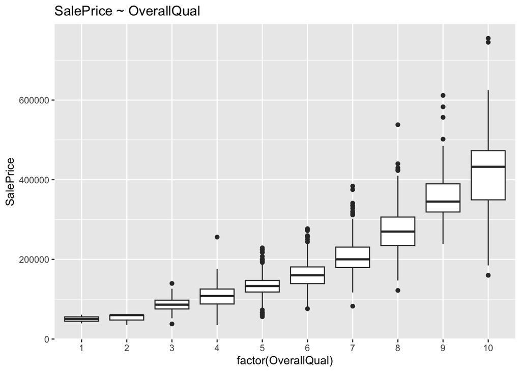

```r
train %>%
  ggplot(aes(factor(OverallQual), SalePrice)) +
  geom_boxplot() +
  labs(title = "SalePrice ~ OverallQual")
```

> In the plot we can see that the OverallQual variable has a postive corealtion with the target variable SalePrice. We have taken the OverallQual on the X-axis and SalePrice on Y-axis to observe the relation between those predictors.

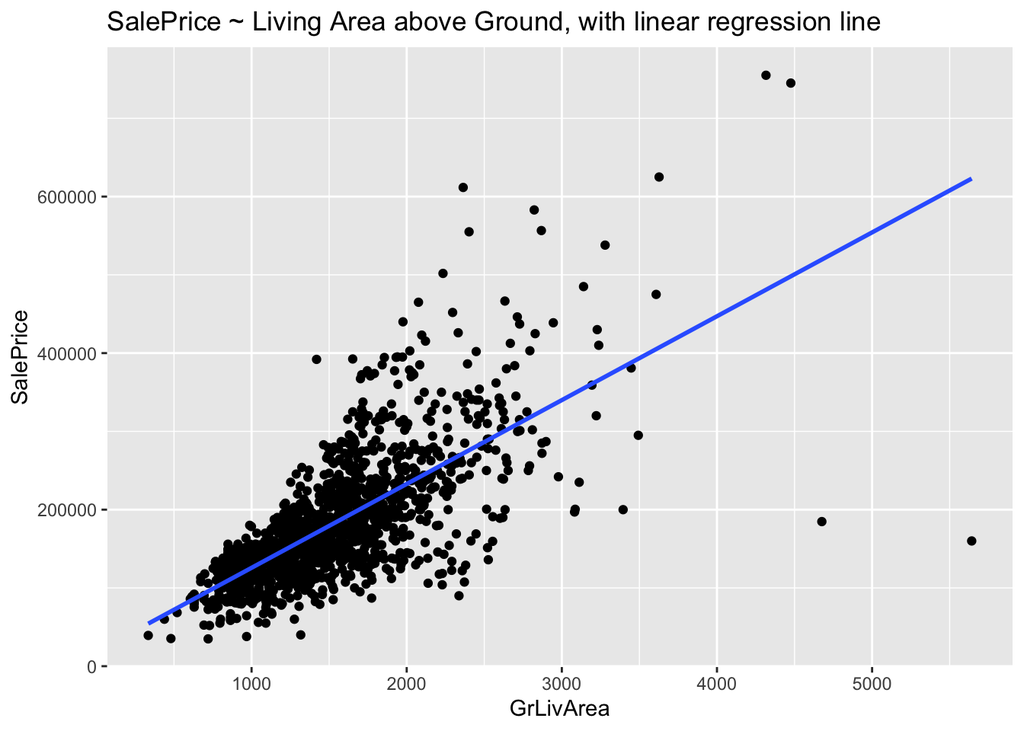

```r
train %>%
  ggplot(aes(GrLivArea, SalePrice)) +
  geom_point() +
  geom_smooth(method = "lm", se = F) +
  labs(title = "SalePrice ~ Living Area above Ground, with linear regression line")
```

> As we can observe from the above plot that the Living area above Ground on X-axis has a positive linear relation to the Salesprice on Y-axis. When the Area is increasing the Salesprice is also increasing.

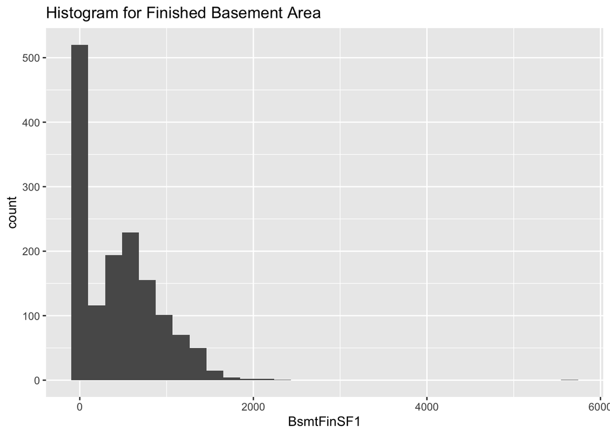

```r
train %>%
  ggplot(aes(BsmtFinSF1)) +
  geom_histogram() +
  labs(title = "Histogram for Finished Basement Area")
```

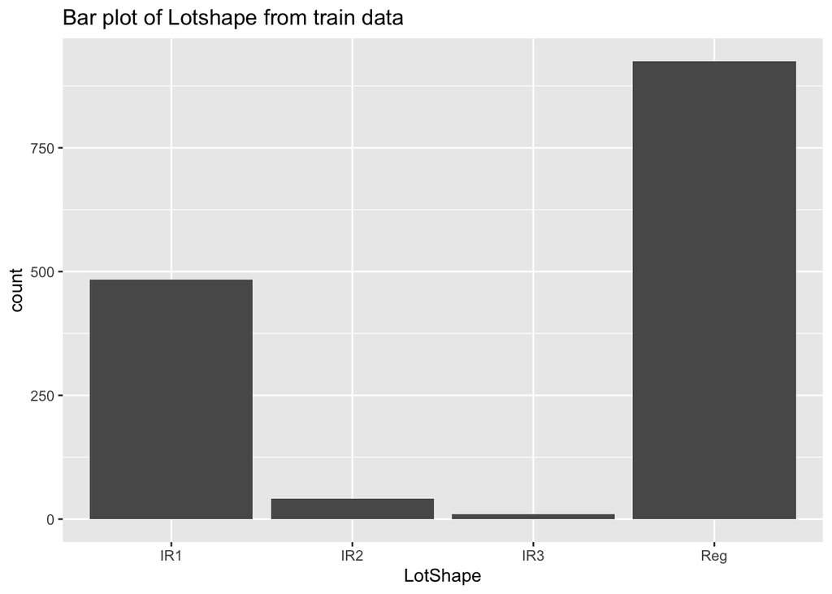

```r
train %>%
  ggplot(aes(LotShape)) +
  geom_bar() +
  labs(title = "Bar plot of Lotshape from train data")
```

> From the above plot we can see that in the LotShape the IR1 and Reg are most popular one while the IR2 and IR3 are not so popular. From this we can say that the Irregular type Lots have less Sales than the Regular and Slighly irregular ones.So, this can be considered as a very good predictor for calculation of SalePrice of Homes

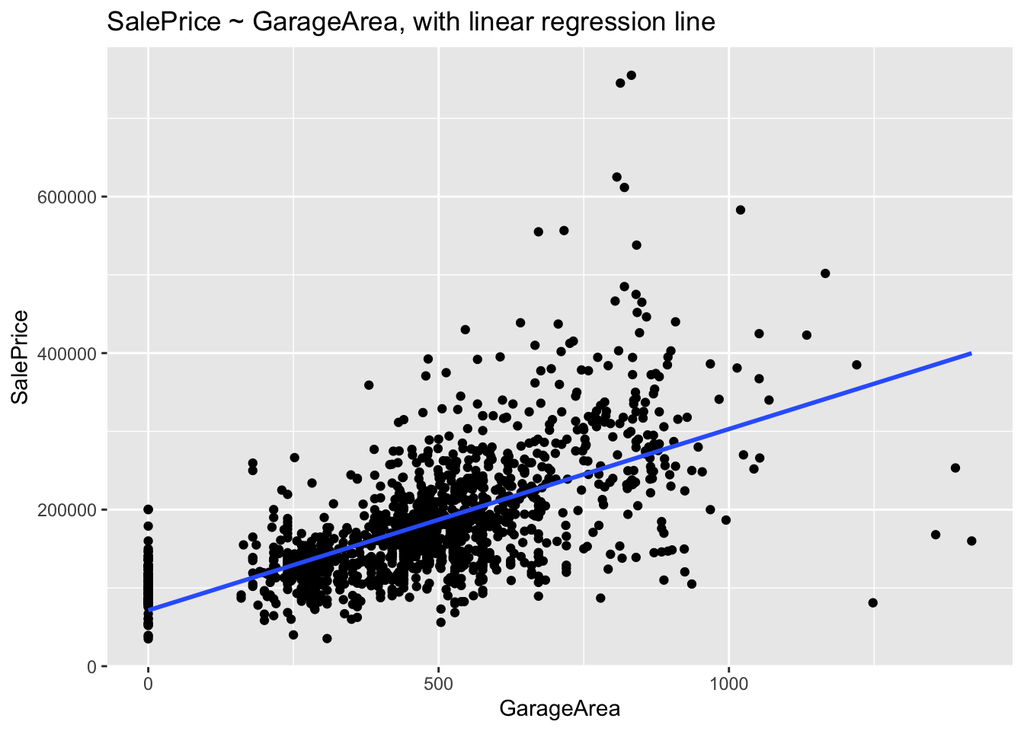

```r
train %>%
  ggplot(aes(GarageArea, SalePrice)) +
  geom_point() +
  geom_smooth(method = "lm", se = F) +
  labs(title = "SalePrice ~ GarageArea, with linear regression line")
```

> Similar to the Living Area we can aslo consider the factor of Garage Area as in the United States from where we are considerding the data, the people are most dependent on the personal transportation rater than public transport which makes the Garage Space most important to fit the cars they own. So when we see the Plot with GarageArea on X-axis and SalePrice on Y-axis we can see that apart from the values at GarageArea = 0, the plot is linear with positive slope. This suggests that when the Garage Space is increasing the SalePrice of those homes are also increased.

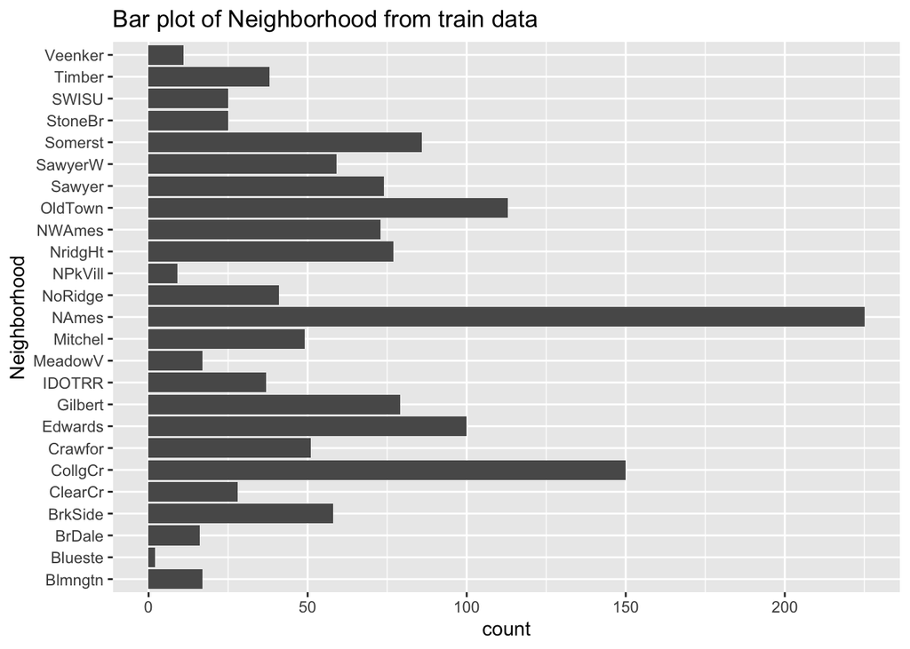

```r
train %>%
  ggplot(aes(y=Neighborhood)) +
  geom_bar() +
  labs(title = "Bar plot of Neighborhood from train data")
```

> From the above Plot we can observe how the Neighborhood will effect the sales of prices. From above plot we can observe that few Neighborhoods have large sales in homes than the others this will effect the sale Prices as the Price of houses in good neighborhood will be more than the prices of houses in bad neighborhood.

> From all the above plots and other consideration we have selected the Predictors for our reggresion model and try to create the model in further steps below.

## Data modeling

From the 1st plot regarding the OverallQual we can understand that the variable is better as a categorical variable rather than numeric. But to get more clarity we use the statistical calculations for checking the R-squared values in linear regression model twice where the OverallQual can be used as numeric once and as factor once and compare. silimarly we compare for OverallCond too.

```r
lm(SalePrice ~ OverallQual, data = train) %>% summary() # R-squared .62
```

```
##
## Call:
## lm(formula = SalePrice ~ OverallQual, data = train)
##
## Residuals:
##     Min      1Q  Median      3Q     Max
## -198152  -29409   -1845   21463  396848
##
## Coefficients:
##             Estimate Std. Error t value Pr(>|t|)
## (Intercept)   -96206       5756   -16.7   <2e-16 ***
## OverallQual    45436        920    49.4   <2e-16 ***
## ---
## Signif. codes:  0 '***' 0.001 '**' 0.01 '*' 0.05 '.' 0.1 ' ' 1
##
## Residual standard error: 48600 on 1458 degrees of freedom
## Multiple R-squared:  0.626,  Adjusted R-squared:  0.625
## F-statistic: 2.44e+03 on 1 and 1458 DF,  p-value: <2e-16
```

```r
lm(SalePrice ~ factor(OverallQual), data = train) %>% summary() # .68
```

```
##
## Call:
## lm(formula = SalePrice ~ factor(OverallQual), data = train)
##
## Residuals:
##     Min      1Q  Median      3Q     Max
## -278588  -24023   -2113   19312  316412
##
## Coefficients:
##                       Estimate Std. Error t value Pr(>|t|)
## (Intercept)              50150      31666    1.58  0.11348
## factor(OverallQual)2      1620      40881    0.04  0.96839
## factor(OverallQual)3     37324      33212    1.12  0.26128
## factor(OverallQual)4     58271      31938    1.82  0.06829 .
## factor(OverallQual)5     83373      31746    2.63  0.00872 **
## factor(OverallQual)6    111453      31751    3.51  0.00046 ***
## factor(OverallQual)7    157566      31766    4.96  7.9e-07 ***
## factor(OverallQual)8    224586      31854    7.05  2.8e-12 ***
## factor(OverallQual)9    317363      32395    9.80  < 2e-16 ***
## factor(OverallQual)10   388438      33380   11.64  < 2e-16 ***
## ---
## Signif. codes:  0 '***' 0.001 '**' 0.01 '*' 0.05 '.' 0.1 ' ' 1
##
## Residual standard error: 44800 on 1450 degrees of freedom
## Multiple R-squared:  0.684,  Adjusted R-squared:  0.682
## F-statistic:  349 on 9 and 1450 DF,  p-value: <2e-16
```

```r
lm(SalePrice ~ OverallCond, data = train) %>% summary() # R-squared 0.00538
```

```
##
## Call:
## lm(formula = SalePrice ~ OverallCond, data = train)
##
## Residuals:
##     Min      1Q  Median      3Q     Max
## -159924  -49459  -16590   30881  576439
##
## Coefficients:
##             Estimate Std. Error t value Pr(>|t|)
## (Intercept)   211910      10597   20.00   <2e-16 ***
## OverallCond    -5558       1864   -2.98   0.0029 **
## ---
## Signif. codes:  0 '***' 0.001 '**' 0.01 '*' 0.05 '.' 0.1 ' ' 1
##
## Residual standard error: 79200 on 1458 degrees of freedom
## Multiple R-squared:  0.00606,    Adjusted R-squared:  0.00538
## F-statistic: 8.89 on 1 and 1458 DF,  p-value: 0.00291
```

```r
lm(SalePrice ~ factor(OverallCond), data = train) %>% summary() # 0.1206
```

```
##
## Call:
## lm(formula = SalePrice ~ factor(OverallCond), data = train)
##
## Residuals:
##     Min      1Q  Median      3Q     Max
## -168247  -43659  -14146   27688  601038
##
## Coefficients:
##                      Estimate Std. Error t value Pr(>|t|)
## (Intercept)             61000      74500    0.82    0.413
## factor(OverallCond)2    80986      81610    0.99    0.321
## factor(OverallCond)3    40929      75975    0.54    0.590
## factor(OverallCond)4    59438      75150    0.79    0.429
## factor(OverallCond)5   142147      74545    1.91    0.057 .
## factor(OverallCond)6    92962      74647    1.25    0.213
## factor(OverallCond)7    97146      74681    1.30    0.194
## factor(OverallCond)8    94652      75015    1.26    0.207
## factor(OverallCond)9   155004      76174    2.03    0.042 *
## ---
## Signif. codes:  0 '***' 0.001 '**' 0.01 '*' 0.05 '.' 0.1 ' ' 1
##
## Residual standard error: 74500 on 1451 degrees of freedom
## Multiple R-squared:  0.125,  Adjusted R-squared:  0.121
## F-statistic:   26 on 8 and 1451 DF,  p-value: <2e-16
```

> From the above summaries we can find that the R-squared value is more when the variavle is converted to factor so we are converting the numeric variable as categorical variable in the train data as below.

```r
train$OverallQual <- as.factor(train$OverallQual)
train$OverallCond <- as.factor(train$OverallCond)
```

## Cross validation

Cross-validation (CV) a method to avoid over fitting by estimating the model’s performance with new data. Since we will not have access to new data we will set aside a part of the available data to test the performance, while we use the remaining data to fit into the model. RMSE and R-squared on the test data will be the estimate of the model’s out of sample performance. General split proportion of 70/30 is used

```r
# Randomly sample 70% of the rows
set.seed(123)
index <- sample(1:nrow(train), nrow(train)*.7, replace = F)

head(index) # These are row numbers
```

```
## [1] 415 463 179 526 195 938
```

```r
# Subset train using the index to create train_fold
train_fold <- train[index, ]

# Subset the remaining row to create validation fold.
validation_fold <- train[-index, ]
```

## Modeling Process

Apart from the predictors mentioned above, we have other Predictors like Total Basement Area(TotalBsmtSF), Basement Quality (BsmtQual), Exposure of Basement to outside area(BsmtExposure), Number of Fireplaces(Fireplaces), Year of remodelling(YearRemodAdd), Style of House(HouseStyle), Total Number of rooms above Ground Level(TotRmsAbvGrd), MSSubClass which tells the type of dwelling involved in the sale are effecting the Sale Price of the homes to a great extent. So we are using these predictors to build our regression model. Additionally, from the train data we can see that the LotShape, BsmtFinSF1 and GrLivArea is highly effecting the SalePrice so we are using these predictors in interaction with each other.

## Model Fit

By using the cross validation we have got the `train_fold` data on which we will fit model by using the above mentioned predictors using the linear regression model.

```r
# Fit model
model <- lm(SalePrice ~ LotShape * BsmtFinSF1 * GrLivArea  + TotalBsmtSF +
              LotArea + Fireplaces +  Neighborhood + OverallQual + OverallCond +
              YearRemodAdd +  YearBuilt + HouseStyle + LotFrontage + BsmtQual +
              MSSubClass + BsmtExposure + GarageArea + TotRmsAbvGrd ,
            data = train_fold)
model %>%  summary()
```

```
##
## Call:
## lm(formula = SalePrice ~ LotShape * BsmtFinSF1 * GrLivArea +
##     TotalBsmtSF + LotArea + Fireplaces + Neighborhood + OverallQual +
##     OverallCond + YearRemodAdd + YearBuilt + HouseStyle + LotFrontage +
##     BsmtQual + MSSubClass + BsmtExposure + GarageArea + TotRmsAbvGrd,
##     data = train_fold)
##
## Residuals:
##     Min      1Q  Median      3Q     Max
## -335892  -10303       0   10407  202615
##
## Coefficients:
##                                   Estimate Std. Error t value   Pr(>|t|)
## (Intercept)                      -9.83e+05   1.85e+05   -5.31 0.00000014 ***
## LotShapeIR2                      -3.31e+04   2.93e+04   -1.13    0.25862
## LotShapeIR3                       1.02e+04   4.25e+04    0.24    0.81006
## LotShapeReg                       3.30e+04   9.29e+03    3.55    0.00041 ***
## BsmtFinSF1                        3.52e+01   8.92e+00    3.95 0.00008479 ***
## GrLivArea                         6.42e+01   6.30e+00   10.20    < 2e-16 ***
## TotalBsmtSF                       1.44e+01   5.23e+00    2.74    0.00617 **
## LotArea                           1.63e-01   1.26e-01    1.29    0.19628
## Fireplaces                        7.63e+03   1.74e+03    4.39 0.00001258 ***
## NeighborhoodBlueste              -2.09e+04   2.89e+04   -0.72    0.47012
## NeighborhoodBrDale               -1.50e+04   1.27e+04   -1.18    0.23782
## NeighborhoodBrkSide              -1.00e+04   1.09e+04   -0.91    0.36071
## NeighborhoodClearCr              -1.94e+04   1.10e+04   -1.76    0.07907 .
## NeighborhoodCollgCr              -9.14e+03   8.70e+03   -1.05    0.29410
## NeighborhoodCrawfor               9.94e+03   1.03e+04    0.96    0.33587
## NeighborhoodEdwards              -2.34e+04   9.64e+03   -2.43    0.01547 *
## NeighborhoodGilbert              -9.10e+03   9.36e+03   -0.97    0.33135
## NeighborhoodIDOTRR               -2.26e+04   1.14e+04   -1.99    0.04706 *
## NeighborhoodMeadowV              -2.25e+04   1.26e+04   -1.79    0.07322 .
## NeighborhoodMitchel              -2.17e+04   9.69e+03   -2.24    0.02506 *
## NeighborhoodNAmes                -1.77e+04   9.30e+03   -1.90    0.05720 .
## NeighborhoodNoRidge               2.71e+04   1.03e+04    2.63    0.00876 **
## NeighborhoodNPkVill              -3.19e+03   1.35e+04   -0.24    0.81362
## NeighborhoodNridgHt               1.91e+04   9.07e+03    2.10    0.03565 *
## NeighborhoodNWAmes               -2.32e+04   9.54e+03   -2.43    0.01514 *
## NeighborhoodOldTown              -2.09e+04   1.03e+04   -2.03    0.04295 *
```

[output cut: 46 more lines]

```
## LotShapeIR3:BsmtFinSF1            1.97e+01   2.83e+01    0.70    0.48717
## LotShapeReg:BsmtFinSF1           -3.56e+01   1.32e+01   -2.71    0.00692 **
## LotShapeIR2:GrLivArea             2.00e+01   1.57e+01    1.28    0.20131
## LotShapeIR3:GrLivArea            -4.24e+00   2.45e+01   -0.17    0.86248
## LotShapeReg:GrLivArea            -2.20e+01   5.59e+00   -3.93 0.00008981 ***
## BsmtFinSF1:GrLivArea             -1.06e-02   4.38e-03   -2.41    0.01601 *
## LotShapeIR2:BsmtFinSF1:GrLivArea  1.60e-02   1.98e-02    0.81    0.41896
## LotShapeIR3:BsmtFinSF1:GrLivArea -1.57e-02   7.39e-03   -2.12    0.03436 *
## LotShapeReg:BsmtFinSF1:GrLivArea  2.23e-02   7.19e-03    3.10    0.00197 **
## ---
## Signif. codes:  0 '***' 0.001 '**' 0.01 '*' 0.05 '.' 0.1 ' ' 1
##
## Residual standard error: 27400 on 940 degrees of freedom
## Multiple R-squared:  0.89,   Adjusted R-squared:  0.881
## F-statistic: 95.5 on 80 and 940 DF,  p-value: <2e-16
```

> Here we can see that the model has provided the RMSE value of 27400 and the R-squared value of 0.881 for the data on the train_fold. This can be tested now on the validation_fold to get the estimated RMSE and R-squared values.

```r
# Get predictions for the validation fold
predictions <- predict(model, newdata = validation_fold)

# Create functions for calculating RMSE and R-squared
rmse <- function(observed, predicted) sqrt(mean((observed - predicted)^2))

R2 <- function(observed, predicted){
  TSS <- sum((observed - mean(observed))^2)
  RSS <- sum((observed - predicted)^2)
  1- RSS/TSS
}

rmse(validation_fold$SalePrice, predictions)
```

```
## [1] 23402
```

```r
R2(validation_fold$SalePrice, predictions)
```

```
## [1] 0.913
```

> Now when the model is implimented to the validation_fold and we calculate the RMSE and R-squared values by using the formula we will get RMSE value as 23402 and R-squared value as 0.913 which meets the benchmark performance of 0.85 R-squared. These are the estimated RMSE and R-squared values for the test data.

## Submission to kaggle

Now to submit into kaggle we need to get the SalePrice variable values for the test dataset. So first create the submission model for entire train dataset

```r
# 1. Fit your model to the entire train set.
submission_model <- lm(SalePrice ~ LotShape * BsmtFinSF1 * GrLivArea  + TotalBsmtSF +
              LotArea + Fireplaces +  Neighborhood + OverallQual + OverallCond +
              YearRemodAdd +  YearBuilt + HouseStyle + LotFrontage + BsmtQual +
              MSSubClass + BsmtExposure + GarageArea + TotRmsAbvGrd  ,
            data = train)
```

```r
# 2. Make exactly the same changes to the test set that you made to the train set.
test %>%
  summarize_all(count_missings)
```

```
## # A tibble: 1 × 80
##      Id MSSubClass MSZoning LotFr…¹ LotArea Street Alley LotSh…² LandC…³ Utili…⁴
##   <int>      <int>    <int>   <int>   <int>  <int> <int>   <int>   <int>   <int>
## 1     0          0        4     227       0      0  1352       0       0       2
## # … with 70 more variables: LotConfig <int>, LandSlope <int>,
## #   Neighborhood <int>, Condition1 <int>, Condition2 <int>, BldgType <int>,
## #   HouseStyle <int>, OverallQual <int>, OverallCond <int>, YearBuilt <int>,
## #   YearRemodAdd <int>, RoofStyle <int>, RoofMatl <int>, Exterior1st <int>,
## #   Exterior2nd <int>, MasVnrType <int>, MasVnrArea <int>, ExterQual <int>,
## #   ExterCond <int>, Foundation <int>, BsmtQual <int>, BsmtCond <int>,
## #   BsmtExposure <int>, BsmtFinType1 <int>, BsmtFinSF1 <int>, …
```

```r
test <- test %>%
  mutate(Alley = replace_na(data = Alley, replace = "none")) %>%
  mutate(BsmtQual = replace_na(data = BsmtQual, replace = "none")) %>%
  mutate(BsmtCond = replace_na(data = BsmtCond, replace = "none") ) %>%
  mutate(PoolQC = replace_na(data = PoolQC, replace = "NoP")) %>%
  mutate(Fence = replace_na(data = Fence, replace = "NoF")) %>%
  mutate(MiscFeature= replace_na(data=MiscFeature, replace = "None")) %>%
  mutate(GarageQual = replace_na(data = GarageQual, replace = "No")) %>%
  mutate(GarageCond = replace_na(data = GarageCond, replace = "No")) %>%
  mutate(GarageType = replace_na(data = GarageType, replace = "NoGar")) %>%
  mutate(GarageYrBlt = replace_na(data = GarageYrBlt, replace = 0 )) %>%
  mutate(GarageCars = replace_na(data = GarageCars, replace = 0 )) %>%
  mutate(GarageFinish = replace_na(data = GarageFinish, replace = "No")) %>%
  mutate(FireplaceQu = replace_na(data = FireplaceQu, replace = "No")) %>%
  mutate(BsmtExposure = replace_na(data = BsmtExposure, replace = "None")) %>%
  mutate(BsmtFinType1 = replace_na(data = BsmtFinType1, replace = "No")) %>%
  mutate(BsmtFinType2 = replace_na(data = BsmtFinType2, replace = "No")) %>%
  mutate(LotFrontage = replace_na(LotFrontage, median(LotFrontage, na.rm = T))) %>%
  mutate(BsmtFinSF1 = replace_na(BsmtFinSF1, median(BsmtFinSF1, na.rm = T))) %>%
  mutate(TotalBsmtSF = replace_na(TotalBsmtSF, median(TotalBsmtSF, na.rm = T))) %>%
  mutate(GarageArea = replace_na(GarageArea, median(GarageArea, na.rm = T)))

test$OverallQual <- as.factor(test$OverallQual)
test$OverallCond <- as.factor(test$OverallCond)
```

```r
# 3. Check there are no missing observations for your selected predictors in the test set.
test %>%
  summarize_all(count_missings)
```

```
## # A tibble: 1 × 80
##      Id MSSubClass MSZoning LotFr…¹ LotArea Street Alley LotSh…² LandC…³ Utili…⁴
##   <int>      <int>    <int>   <int>   <int>  <int> <int>   <int>   <int>   <int>
## 1     0          0        4       0       0      0     0       0       0       2
## # … with 70 more variables: LotConfig <int>, LandSlope <int>,
## #   Neighborhood <int>, Condition1 <int>, Condition2 <int>, BldgType <int>,
## #   HouseStyle <int>, OverallQual <int>, OverallCond <int>, YearBuilt <int>,
## #   YearRemodAdd <int>, RoofStyle <int>, RoofMatl <int>, Exterior1st <int>,
## #   Exterior2nd <int>, MasVnrType <int>, MasVnrArea <int>, ExterQual <int>,
## #   ExterCond <int>, Foundation <int>, BsmtQual <int>, BsmtCond <int>,
## #   BsmtExposure <int>, BsmtFinType1 <int>, BsmtFinSF1 <int>, …
```

```r
# 4. Make predictions for the test set.
submission_predictions <- predict(submission_model, newdata = test) # Use the newdata argument!

head(submission_predictions)
```

```
##      1      2      3      4      5      6
## 123620 153331 184013 192424 212883 173039
```

```r
# 5. Format your submission file.

submission <- test %>%
  select(Id) %>%
  mutate(SalePrice = submission_predictions)

# Check
head(submission)
```

```
## # A tibble: 6 × 2
##      Id SalePrice
##   <dbl>     <dbl>
## 1  1461   123620.
## 2  1462   153331.
## 3  1463   184013.
## 4  1464   192424.
## 5  1465   212883.
## 6  1466   173039.
```

```r
write.csv(submission,"submission_final.csv")
```

## Kaggle Results

Rank - 1951 and Score - 0.14493. This kaggle score meets the performance benchmark of 0.15.

[figure not shown]

## Group Members and Contributions

The StatsTeam Group is consisting of the below Group Members:

1. Kushal Ram Tayi (IS 6489 - 001)
2. Simran Khan Pathan (IS 6489 - 001)
3. Sai Anogna Chittudi (IS 6489 - 090)

We have worked as a team and all of us has equally contributed into the project. To be more specific, Kushal had great role in predictors selection, Simran contributed more for the Team coordination and dataset cross validation and Sai Anogna have contributed more in Data Visualization part. But the model design and checking whether it meets the specifications and also kaggle submissions has done by all collectively to make the project successful.